# Social_Project

```r
#its hard to see a good group choice, maybe 5 groups, namely first 4 ID and the remaing right part

#try K-means for a best result
#set the range of cluster numbers
min_clusters <- 2
max_clusters <- 20

#initialize a vector to store the percentage of variance explained
Variance_List <- numeric(max_clusters - min_clusters + 1)

#loop over the range of cluster numbers
for (k in min_clusters:max_clusters) {
  set.seed(123)  # Set a seed for reproducibility
  kmeans_result <- kmeans(DataSetScaled, centers = k, nstart = 10)
  perc <- round(100 * (1 - kmeans_result$betweenss / kmeans_result$totss), 1)
  Variance_List[k - min_clusters + 1] <- perc
  cat("Variance explained for", k, "clusters:", perc, "%\n")
}
```

```
## Variance explained for 2 clusters: 84.4 %
## Variance explained for 3 clusters: 73.4 %
## Variance explained for 4 clusters: 62.9 %
## Variance explained for 5 clusters: 52.7 %
## Variance explained for 6 clusters: 44.2 %
## Variance explained for 7 clusters: 38.7 %
## Variance explained for 8 clusters: 32.5 %
## Variance explained for 9 clusters: 27.7 %
## Variance explained for 10 clusters: 23.9 %
## Variance explained for 11 clusters: 20.5 %
## Variance explained for 12 clusters: 17.8 %
## Variance explained for 13 clusters: 15.3 %
## Variance explained for 14 clusters: 12.7 %
## Variance explained for 15 clusters: 10.4 %
## Variance explained for 16 clusters: 8.1 %
## Variance explained for 17 clusters: 6.1 %
## Variance explained for 18 clusters: 4.4 %
## Variance explained for 19 clusters: 2.9 %
## Variance explained for 20 clusters: 1.5 %
```

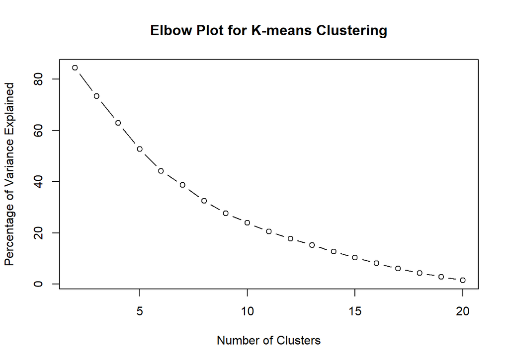

```r
plot(min_clusters:max_clusters, Variance_List, type = "b",
     xlab = "Number of Clusters",
     ylab = "Percentage of Variance Explained",
     main = "Elbow Plot for K-means Clustering")
```

Obviously, 5~8 groups are the best choices.

```r
library(factoextra)
library(FactoMineR)
library(ggfortify)
library(psych)
library(corrplot)
library(devtools)
kmeans5 <- kmeans(DataSetScaled,5,nstart = 10)

#saving four k-means clusters in a list
clus1 <- matrix(names(kmeans5$cluster[kmeans5$cluster == 1]),
                ncol=1, nrow=length(kmeans5$cluster[kmeans5$cluster == 1]))
colnames(clus1) <- "Cluster 1"
clus2 <- matrix(names(kmeans5$cluster[kmeans5$cluster == 2]),
                ncol=1, nrow=length(kmeans5$cluster[kmeans5$cluster == 2]))
colnames(clus2) <- "Cluster 2"
clus3 <- matrix(names(kmeans5$cluster[kmeans5$cluster == 3]),
                ncol=1, nrow=length(kmeans5$cluster[kmeans5$cluster == 3]))
colnames(clus3) <- "Cluster 3"
clus4 <- matrix(names(kmeans5$cluster[kmeans5$cluster == 4]),
                ncol=1, nrow=length(kmeans5$cluster[kmeans5$cluster == 4]))
colnames(clus4) <- "Cluster 4"
clus5 <- matrix(names(kmeans5$cluster[kmeans5$cluster == 5]),
                ncol=1, nrow=length(kmeans5$cluster[kmeans5$cluster == 5]))
colnames(clus5) <- "Cluster 5"
list(clus1,clus2,clus3,clus4,clus5)
```

```
## [[1]]
##      Cluster 1
## [1,] "15801"
##
## [[2]]
##       Cluster 2
##  [1,] "peace"
##  [2,] "tl868"
##  [3,] "trave"
##  [4,] "19!@s"
##  [5,] "ki567"
##  [6,] "ak2001"
##  [7,] "Harvey"
##  [8,] "hahah"
##  [9,] "sss32"
## [10,] "MVA37@S"
## [11,] "2134"
## [12,] "Baiqi"
##
## [[3]]
##      Cluster 3
## [1,] "Patty"
## [2,] "Bunny"
## [3,] "drphy"
## [4,] "yh2020"
## [5,] "vp1234"
##
## [[4]]
##      Cluster 4
## [1,] "masinl"
## [2,] "AKIRA"
##
## [[5]]
##      Cluster 5
## [1,] "ds2134"
```

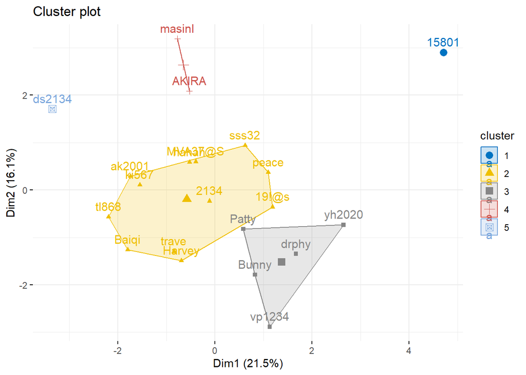

```r
fviz_cluster(kmeans5, data = DataSetScaled,
             ellipse.type = "convex",
             palette = "jco",
             ggtheme = theme_minimal())
```

Lets check the means difference between groups, especial the feeling of week.

```r
means_list <- lapply(1:5, function(k) {
  cluster_rows <- which(kmeans5$cluster == k)
  colMeans(DataSet[cluster_rows, c('LearningItem','Mood','TiredWakeUP','TroubleSleep','WeekFelt')])
})

names(means_list) <- paste("Cluster", 1:5)
means_list
```

```
## $`Cluster 1`
## LearningItem         Mood  TiredWakeUP TroubleSleep     WeekFelt
##            1            1            0            1            3
##
## $`Cluster 2`
## LearningItem         Mood  TiredWakeUP TroubleSleep     WeekFelt
##    2.8333333    1.0000000    0.5000000    0.4166667    3.4166667
##
## $`Cluster 3`
## LearningItem         Mood  TiredWakeUP TroubleSleep     WeekFelt
##          4.6          1.0          0.2          0.2          4.2
##
## $`Cluster 4`
## LearningItem         Mood  TiredWakeUP TroubleSleep     WeekFelt
##            2            1            0            0            3
##
## $`Cluster 5`
## LearningItem         Mood  TiredWakeUP TroubleSleep     WeekFelt
##            2            0            0            0            2
```

```r
#we can see some groups are wield, like gourp 5, only one ID, no Tired thing but WeekFelt is 2,
#I think this is some kind of mistype and should be excluded.
#In group 3, we can see that they have good sleep condition and high WeekFelt, we can check
#their App usage after.Group 2 have a bad sleep, which may mean they use social media too much.

means_list <- lapply(1:5, function(k) {
  cluster_rows <- which(kmeans5$cluster == k)
  colMeans(DataSet[cluster_rows, c('InsTime','WhatsappTime','LinkedinTime','OTTTime','TwitterTime')])
})

names(means_list) <- paste("Cluster", 1:5)
means_list
```

```
## $`Cluster 1`
##      InsTime WhatsappTime LinkedinTime      OTTTime  TwitterTime
##          901          921          237          600            0
##
## $`Cluster 2`
##      InsTime WhatsappTime LinkedinTime      OTTTime  TwitterTime
##    309.75000    364.33333    150.33333     60.75000     35.91667
##
## $`Cluster 3`
##      InsTime WhatsappTime LinkedinTime      OTTTime  TwitterTime
##        325.6        459.4        411.8        132.0          0.0
##
## $`Cluster 4`
##      InsTime WhatsappTime LinkedinTime      OTTTime  TwitterTime
##        244.5        225.0        232.5        492.5        150.0
##
## $`Cluster 5`
##      InsTime WhatsappTime LinkedinTime      OTTTime  TwitterTime
##           10           60            0            0            0
```

```r
#The result turns out counter-intuitively that group 2 use less social media, but group 3
#is good in a week with more social media using time. I suppose some other thing influenced their feeling.
#And maybe group 3 is just too busy in their lives. By the way I'm in group 2.
```

Also, the multiple regression can be used to predict the weekly feelings.

```r
fit <- lm(WeekFelt~InsTime+LinkedinTime+TwitterTime+WhatsappTime+OTTTime+JobInterview+LearningItem+TiredWakeUP, data=DataSet)
#show the results
summary(fit)
```

```
##
## Call:
## lm(formula = WeekFelt ~ InsTime + LinkedinTime + TwitterTime +
##     WhatsappTime + OTTTime + JobInterview + LearningItem + TiredWakeUP,
##     data = DataSet)
##
## Residuals:
##      Min       1Q   Median       3Q      Max
## -0.75543 -0.24125 -0.03319  0.19065  0.96043
##
## Coefficients:
##                Estimate Std. Error t value Pr(>|t|)
## (Intercept)   2.2716931  0.4902235   4.634 0.000576 ***
## InsTime      -0.0015105  0.0008036  -1.880 0.084639 .
## LinkedinTime  0.0039677  0.0013301   2.983 0.011422 *
## TwitterTime   0.0096629  0.0033271   2.904 0.013221 *
## WhatsappTime  0.0027450  0.0008393   3.271 0.006696 **
## OTTTime      -0.0025706  0.0009993  -2.572 0.024438 *
## JobInterview  0.7136588  0.2897789   2.463 0.029887 *
## LearningItem -0.2294650  0.1391975  -1.648 0.125167
## TiredWakeUP   0.9763704  0.2892215   3.376 0.005510 **
## ---
## Signif. codes:  0 '***' 0.001 '**' 0.01 '*' 0.05 '.' 0.1 ' ' 1
##
## Residual standard error: 0.5289 on 12 degrees of freedom
## Multiple R-squared:  0.7012, Adjusted R-squared:  0.5021
## F-statistic: 3.521 on 8 and 12 DF,  p-value: 0.02478
```

```r
coefficients(fit)
```

```
##  (Intercept)      InsTime LinkedinTime  TwitterTime WhatsappTime      OTTTime
##  2.271693105 -0.001510462  0.003967686  0.009662861  0.002744986 -0.002570627
## JobInterview LearningItem  TiredWakeUP
##  0.713658802 -0.229464990  0.976370431
```

With the result, we can see the R-squared value of the model is 0.70, which is a acceptable result. Also, most of remaining variables are significant. Now, we can run a residual analysis.

```r
#start a residual analysis
confint(fit,level=0.95)
```

```
##                      2.5 %        97.5 %
## (Intercept)   1.2035879320  3.3397982776
## InsTime      -0.0032612669  0.0002403434
## LinkedinTime  0.0010696515  0.0068657198
## TwitterTime   0.0024136459  0.0169120769
## WhatsappTime  0.0009162971  0.0045736757
## OTTTime      -0.0047479450 -0.0003933093
## JobInterview  0.0822847410  1.3450328630
## LearningItem -0.5327502918  0.0738203122
## TiredWakeUP   0.3462108420  1.6065300192
```

```r
fitted(fit)
```

```
##        1        2        3        4        5        6        7        8
## 3.045458 2.809353 3.989963 4.123394 3.041209 4.322474 4.013740 4.291263
##        9       10       11       12       13       14       15       16
## 3.755431 1.962358 3.471064 3.432656 3.958214 2.741972 3.288461 4.039567
##       17       18       19       20       21
## 3.208767 3.622821 3.241250 2.607400 4.033186
```

```r
residuals(fit)
```

```
##           1           2           3           4           5           6
## -0.04545771  0.19064660  0.01003650 -0.12339375 -0.04120933  0.67752618
##           7           8           9          10          11          12
## -0.01373955 -0.29126315 -0.75543081  0.03764231  0.52893600 -0.43265567
##          13          14          15          16          17          18
##  0.04178577  0.25802840 -0.28846114  0.96043255 -0.20876710 -0.62282052
##          19          20          21
## -0.24125002  0.39260021 -0.03318576
```

```r
#Anova Table
anova(fit)
```

```
## Analysis of Variance Table
##
## Response: WeekFelt
##              Df Sum Sq Mean Sq F value  Pr(>F)
## InsTime       1 0.0447  0.0447  0.1596 0.69653
## LinkedinTime  1 1.5183  1.5183  5.4266 0.03811 *
## TwitterTime   1 0.3136  0.3136  1.1207 0.31062
## WhatsappTime  1 0.5326  0.5326  1.9037 0.19283
## OTTTime       1 0.4616  0.4616  1.6500 0.22321
## JobInterview  1 1.4829  1.4829  5.2999 0.04004 *
## LearningItem  1 0.3385  0.3385  1.2097 0.29297
## TiredWakeUP   1 3.1886  3.1886 11.3964 0.00551 **
## Residuals    12 3.3575  0.2798
## ---
## Signif. codes:  0 '***' 0.001 '**' 0.01 '*' 0.05 '.' 0.1 ' ' 1
```

```r
vcov(fit)
```

```
##                (Intercept)       InsTime  LinkedinTime   TwitterTime
## (Intercept)   2.403190e-01 -1.441513e-04  6.228552e-06 -6.094444e-04
## InsTime      -1.441513e-04  6.457074e-07 -3.071154e-07 -2.610402e-07
## LinkedinTime  6.228552e-06 -3.071154e-07  1.769160e-06  1.819697e-06
## TwitterTime  -6.094444e-04 -2.610402e-07  1.819697e-06  1.106986e-05
## WhatsappTime -1.672831e-04 -2.724387e-07  1.438190e-07  1.887292e-06
## OTTTime       8.960138e-05 -1.854561e-08 -5.707916e-07 -2.634031e-06
## JobInterview  1.672407e-03 -7.531352e-05  1.139671e-05  4.031337e-04
## LearningItem -2.935676e-02  4.375536e-05 -1.252564e-04 -2.141442e-04
## TiredWakeUP  -5.979311e-02  1.468799e-05  1.466153e-04  3.423097e-04
##               WhatsappTime       OTTTime  JobInterview  LearningItem
## (Intercept)  -1.672831e-04  8.960138e-05  1.672407e-03 -2.935676e-02
## InsTime      -2.724387e-07 -1.854561e-08 -7.531352e-05  4.375536e-05
## LinkedinTime  1.438190e-07 -5.707916e-07  1.139671e-05 -1.252564e-04
## TwitterTime   1.887292e-06 -2.634031e-06  4.031337e-04 -2.141442e-04
## WhatsappTime  7.044335e-07 -4.174700e-07  1.181794e-04 -3.096044e-05
## OTTTime      -4.174700e-07  9.986282e-07 -7.682604e-05  6.261434e-05
## JobInterview  1.181794e-04 -7.682604e-05  8.397183e-02 -1.574182e-02
## LearningItem -3.096044e-05  6.261434e-05 -1.574182e-02  1.937594e-02
## TiredWakeUP   3.437374e-05 -6.242843e-05 -2.143221e-03 -6.727110e-03
##                TiredWakeUP
## (Intercept)  -5.979311e-02
## InsTime       1.468799e-05
## LinkedinTime  1.466153e-04
## TwitterTime   3.423097e-04
## WhatsappTime  3.437374e-05
## OTTTime      -6.242843e-05
## JobInterview -2.143221e-03
## LearningItem -6.727110e-03
## TiredWakeUP   8.364910e-02
```

```r
cov2cor(vcov(fit))
```

```
##               (Intercept)     InsTime LinkedinTime TwitterTime WhatsappTime
## (Intercept)   1.000000000 -0.36593730  0.009552332 -0.37365337   -0.4065726
## InsTime      -0.365937299  1.00000000 -0.287342672 -0.09763789   -0.4039530
## LinkedinTime  0.009552332 -0.28734267  1.000000000  0.41119178    0.1288287
## TwitterTime  -0.373653375 -0.09763789  0.411191778  1.00000000    0.6758465
## WhatsappTime -0.406572553 -0.40395299  0.128828688  0.67584653    1.0000000
## OTTTime       0.182902112 -0.02309518 -0.429429722 -0.79222391   -0.4977410
## JobInterview  0.011772836 -0.32343592  0.029568485  0.41812990    0.4859090
## LearningItem -0.430212037  0.39118475 -0.676526741 -0.46238516   -0.2650060
## TiredWakeUP  -0.421722147  0.06319953  0.381122838  0.35572755    0.1416042
##                  OTTTime JobInterview LearningItem TiredWakeUP
## (Intercept)   0.18290211   0.01177284   -0.4302120 -0.42172215
## InsTime      -0.02309518  -0.32343592    0.3911848  0.06319953
## LinkedinTime -0.42942972   0.02956848   -0.6765267  0.38112284
## TwitterTime  -0.79222391   0.41812990   -0.4623852  0.35572755
## WhatsappTime -0.49774097   0.48590905   -0.2650060  0.14160422
## OTTTime       1.00000000  -0.26530152    0.4501326 -0.21599807
## JobInterview -0.26530152   1.00000000   -0.3902625 -0.02557228
## LearningItem  0.45013261  -0.39026246    1.0000000 -0.16709615
## TiredWakeUP  -0.21599807  -0.02557228   -0.1670962  1.00000000
```

```r
temp <- influence.measures(fit)
temp
```

```
## Influence measures of
##   lm(formula = WeekFelt ~ InsTime + LinkedinTime + TwitterTime +      WhatsappTime + OTTTime + JobInterview + LearningItem + TiredWakeUP,      data = DataSet) :
##
##       dfb.1_ dfb.InsT dfb.LnkT  dfb.TwtT dfb.WhtT dfb.OTTT dfb.JbIn dfb.LrnI
## 1  -0.019605  0.08639 -0.04098 -0.092055  0.05034 -0.21373 -0.00992  0.03009
## 2   0.090187  0.14875  0.05577 -0.097216 -0.19167 -0.01370 -0.15918  0.01558
## 3   0.000487 -0.00687  0.00703  0.000528  0.00418 -0.00145 -0.00215 -0.00183
## 4  -0.124987  0.19058  0.03477 -0.056577 -0.14338  0.02280 -0.61634  0.12898
## 5  -0.010436  0.00875  0.05030  0.046615  0.03098 -0.05150  0.03143 -0.05708
## 6   0.010727 -1.34096  0.80561  0.228863  1.01106 -0.12018  0.07552 -0.34952
## 7   0.001609 -0.00294 -0.00723 -0.002290  0.00188  0.00487  0.00572  0.00227
## 8   0.061686  0.01974 -0.19211 -0.122684 -0.12209  0.08891  0.01833  0.16509
## 9   0.657199 -0.71037 -0.56481  0.595469  0.79436 -0.39371  0.24668 -0.84512
## 10  0.118332 -0.02823 -0.06120 -0.095012 -0.07705  0.06469 -0.02762  0.01954
## 11  0.366368  0.13818  0.51813  1.024456  0.14574 -1.09531  0.23030 -0.80036
```

[output cut: 32 more lines]

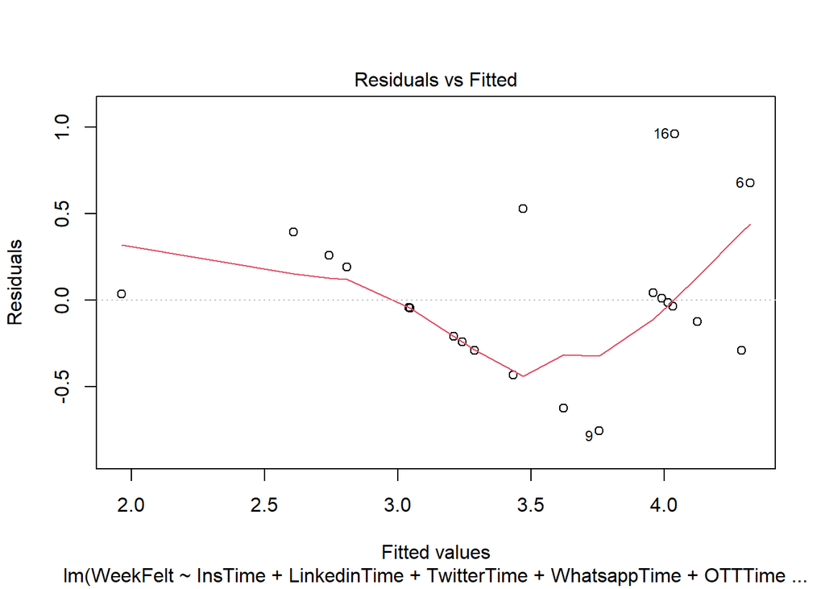

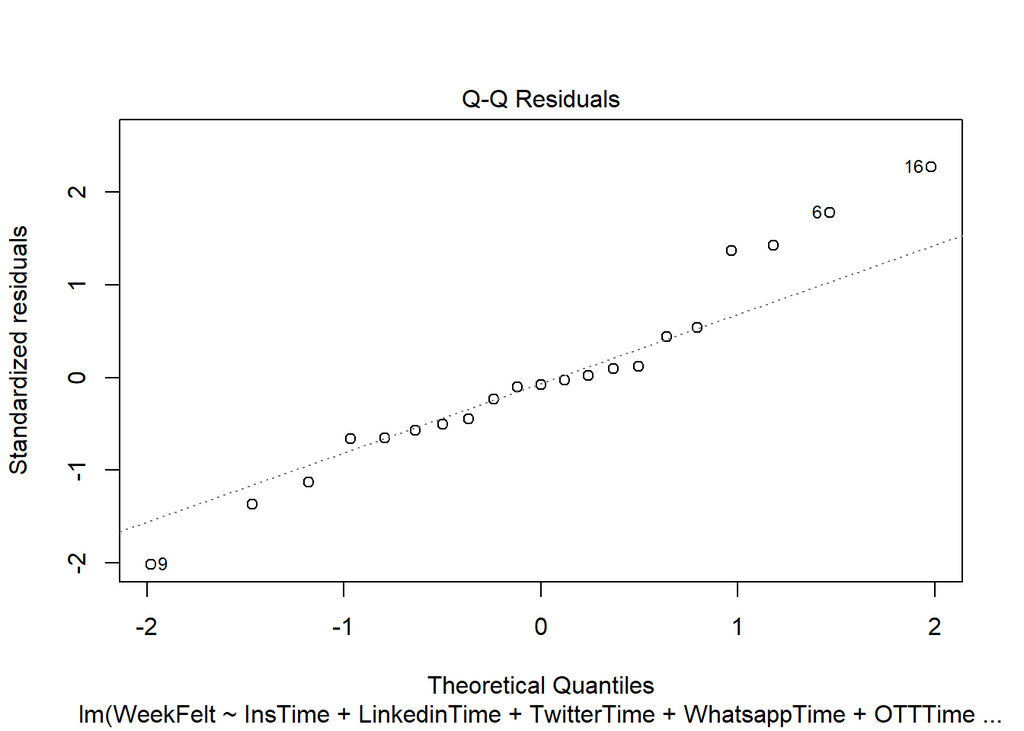

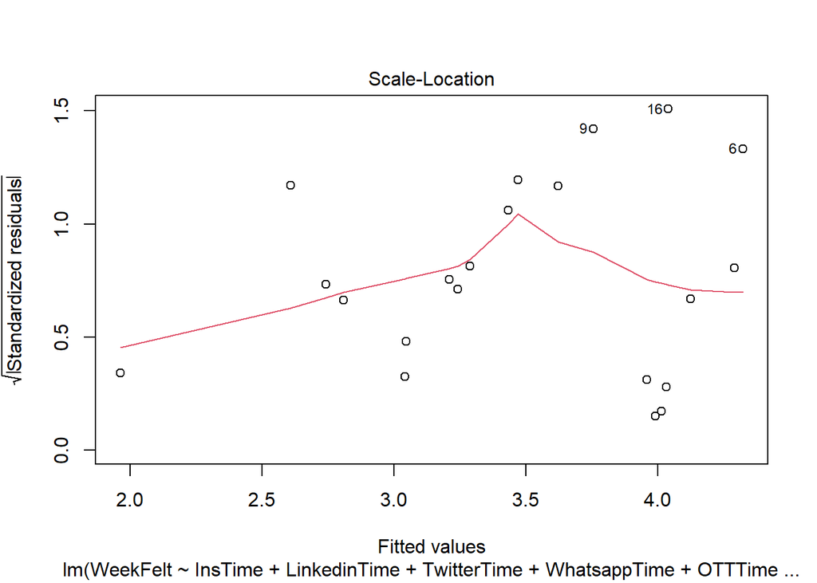

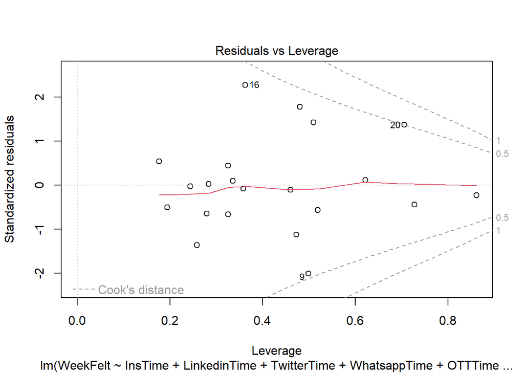

```r
plot(fit)
```

4.Model Insights Before we do the MVA, we need to drop several data columns, especially with all same value.And after dropping and scaling, the distance between rows are quite large, proving that we can do some analysis to find valuable information.

We can cluster the whole class to 5 groups. Some groups are just mistyping, but some of them can provide interesting things. For example, the group 2 uses less social media but feels tired and has a bad sleep. While the group 3 uses a lot of social media but still feels good in a week. The result is quite counter-intuitive and may need more analysis. I think the other factors in lives influence both the social media using-time, sleep, and the weekly feeling.

5.Learnings and Takeaways The usage of various types of apps does not necessarily led to bad sleep and bad week feelings.Sometimes other factors in life will take much time, reducing the smartphone using time as well as making people tired.